# Disaggregated Tagging Patterns

Janette Avelar

2023-06-02

#What are the top tags selected when disaggregated?

##By locale

```r
disag_locale <- full %>%
  select(school_id, locale = exclusive_locale, starts_with("practices")) %>%
  pivot_longer(cols = starts_with("practices"),
               names_to = "tag",
               values_to = "n") %>%
  select(!school_id) %>%
  mutate(rate = rep(1, nrow(.))) %>%
  group_by(locale, tag) %>%
  summarize(n = sum(n),
            rate = sum(rate),
            pct = n/rate) %>%
  ungroup() %>%
  group_by(locale) %>%
  arrange(desc(n), .by_group = TRUE) %>%
  slice(1:5)
```

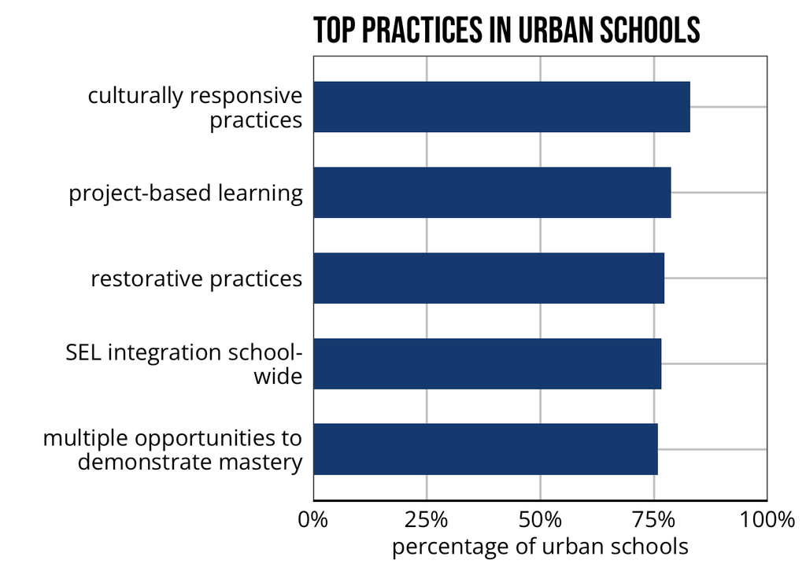

```r
# urban
urban_plot <- disag_locale %>%
  filter(locale == "Urban") %>%
  ggplot(., aes(reorder(tag, pct), pct)) +
  geom_col(fill = transcend_cols[1]) +
  scale_x_discrete(labels = label_tags(wrap = 25)) +
  coord_flip() +
  scale_y_continuous(limits = c(0, 1),
                     expand = c(0,0),
                     labels = scales::percent) +
  labs(title = "Top Practices in Urban Schools",
       x = "",
       y = "percentage of urban schools")
urban_plot
```

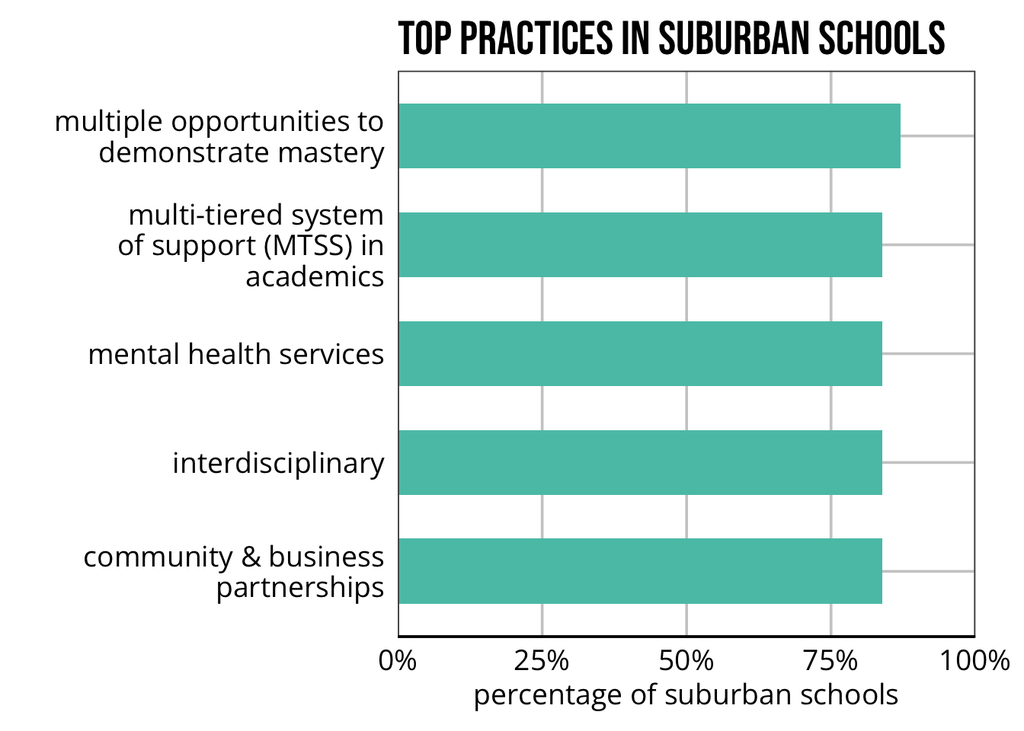

```r
# suburban
suburban_plot <- disag_locale %>%
  filter(locale == "Suburban") %>%
  ggplot(., aes(reorder(tag, pct), pct)) +
  geom_col(fill = transcend_cols[2]) +
  scale_x_discrete(labels = label_tags(wrap = 25)) +
  coord_flip() +
  scale_y_continuous(limits = c(0, 1),
                     expand = c(0,0),
                     labels = scales::percent) +
  labs(title = "Top Practices in Suburban Schools",
       x = "",
       y = "percentage of suburban schools")
suburban_plot
```

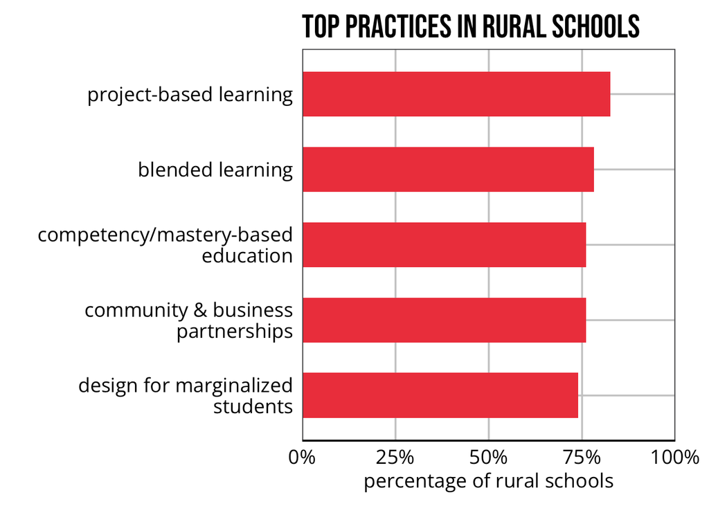

```r
# rural
rural_plot <- disag_locale %>%
  filter(locale == "Rural") %>%
  ggplot(., aes(reorder(tag, pct), pct)) +
  geom_col(fill = transcend_cols[3]) +
  scale_x_discrete(labels = label_tags(wrap = 25)) +
  coord_flip() +
  scale_y_continuous(limits = c(0, 1),
                     expand = c(0,0),
                     labels = scales::percent) +
  labs(title = "Top Practices in Rural Schools",
       x = "",
       y = "percentage of rural schools")
rural_plot
```

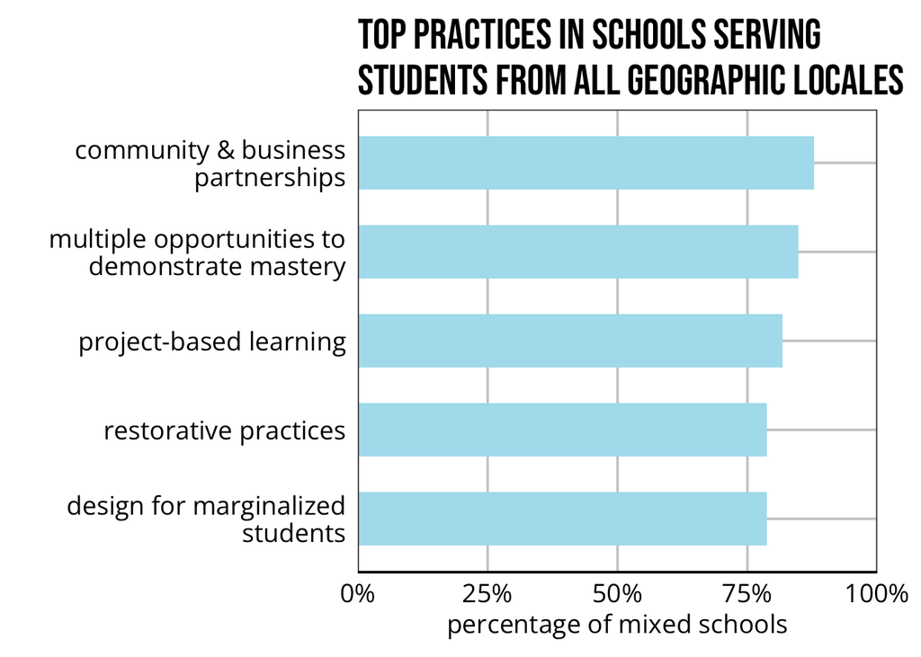

```r
# mixed
mixed_plot <- disag_locale %>%
  filter(locale == "Multiple") %>%
  ggplot(., aes(reorder(tag, pct), pct)) +
  geom_col(fill = transcend_cols[4]) +
  scale_x_discrete(labels = label_tags(wrap = 25)) +
  coord_flip() +
  scale_y_continuous(limits = c(0, 1),
                     expand = c(0,0),
                     labels = scales::percent) +
  labs(title = "Top Practices in Schools Serving\nStudents from all Geographic Locales",
       x = "",
       y = "percentage of mixed schools")
mixed_plot
```

##By level

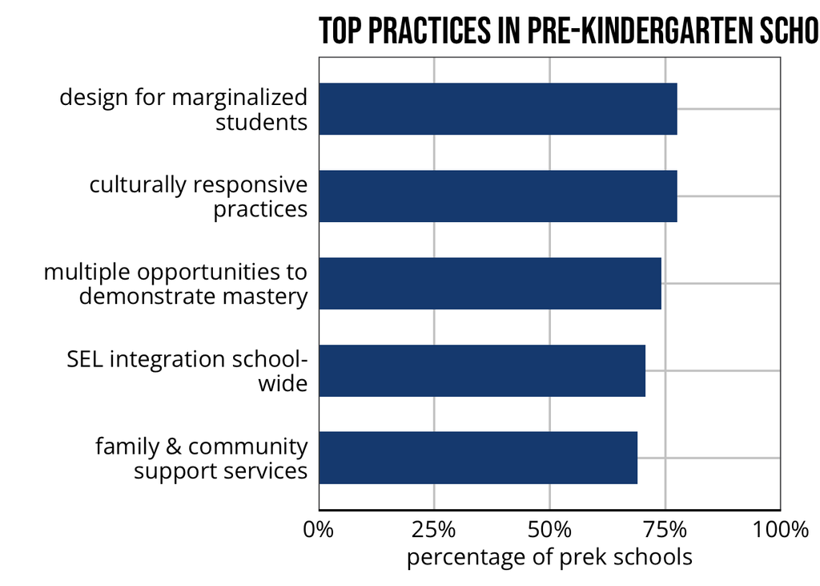

```r
#prekindergarten
disag_pk <- full %>%
  select(school_id, grades_prek, starts_with("practices")) %>%
  filter(grades_prek == 1) %>%
  pivot_longer(cols = starts_with("practices"),
               names_to = "tag",
               values_to = "n") %>%
  select(!school_id) %>%
  mutate(rate = rep(1, nrow(.))) %>%
  group_by(tag) %>%
  summarize(n = sum(n),
            rate = sum(rate),
            pct = n/rate) %>%
  ungroup() %>%
  arrange(desc(n)) %>%
  slice(1:5) %>%
  ggplot(., aes(reorder(tag, pct), pct)) +
  geom_col(fill = transcend_cols[1]) +
  scale_x_discrete(labels = label_tags(wrap = 25)) +
  coord_flip() +
  scale_y_continuous(limits = c(0, 1),
                     expand = c(0,0),
                     labels = scales::percent) +
  labs(title = "Top Practices in Pre-Kindergarten Schools",
       x = "",
       y = "percentage of prek schools")
disag_pk
```

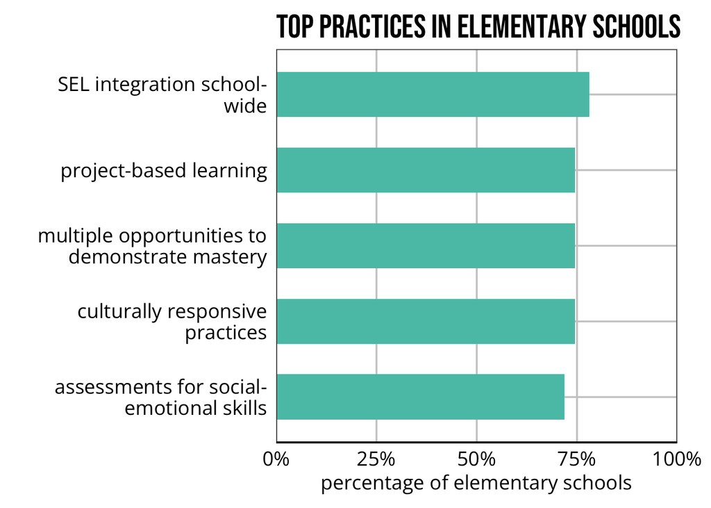

```r
# elementary schools
disag_elem <- full %>%
  select(school_id, grades_elementary, starts_with("practices")) %>%
  filter(grades_elementary == 1) %>%
  pivot_longer(cols = starts_with("practices"),
               names_to = "tag",
               values_to = "n") %>%
  select(!school_id) %>%
  mutate(rate = rep(1, nrow(.))) %>%
  group_by(tag) %>%
  summarize(n = sum(n),
            rate = sum(rate),
            pct = n/rate) %>%
  ungroup() %>%
  arrange(desc(n)) %>%
  slice(1:5) %>%
  ggplot(., aes(reorder(tag, pct), pct)) +
  geom_col(fill = transcend_cols[2]) +
  scale_x_discrete(labels = label_tags(wrap = 25)) +
  coord_flip() +
  scale_y_continuous(limits = c(0, 1),
                     expand = c(0,0),
                     labels = scales::percent) +
  labs(title = "Top Practices in Elementary Schools",
       x = "",
       y = "percentage of elementary schools")
disag_elem
```

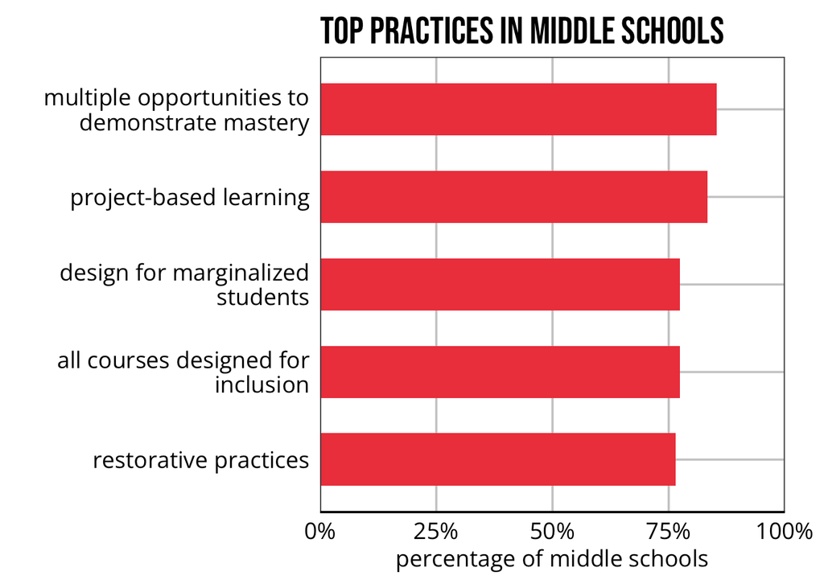

```r
#middle schools
disag_middle <- full %>%
  select(school_id, grades_middle, starts_with("practices")) %>%
  filter(grades_middle == 1) %>%
  pivot_longer(cols = starts_with("practices"),
               names_to = "tag",
               values_to = "n") %>%
  select(!school_id) %>%
  mutate(rate = rep(1, nrow(.))) %>%
  group_by(tag) %>%
  summarize(n = sum(n),
            rate = sum(rate),
            pct = n/rate) %>%
  ungroup() %>%
  arrange(desc(n)) %>%
  slice(1:5) %>%
  ggplot(., aes(reorder(tag, pct), pct)) +
  geom_col(fill = transcend_cols[3]) +
  scale_x_discrete(labels = label_tags(wrap = 25)) +
  coord_flip() +
  scale_y_continuous(limits = c(0, 1),
                     expand = c(0,0),
                     labels = scales::percent) +
  labs(title = "Top Practices in Middle Schools",
       x = "",
       y = "percentage of middle schools")
disag_middle
```

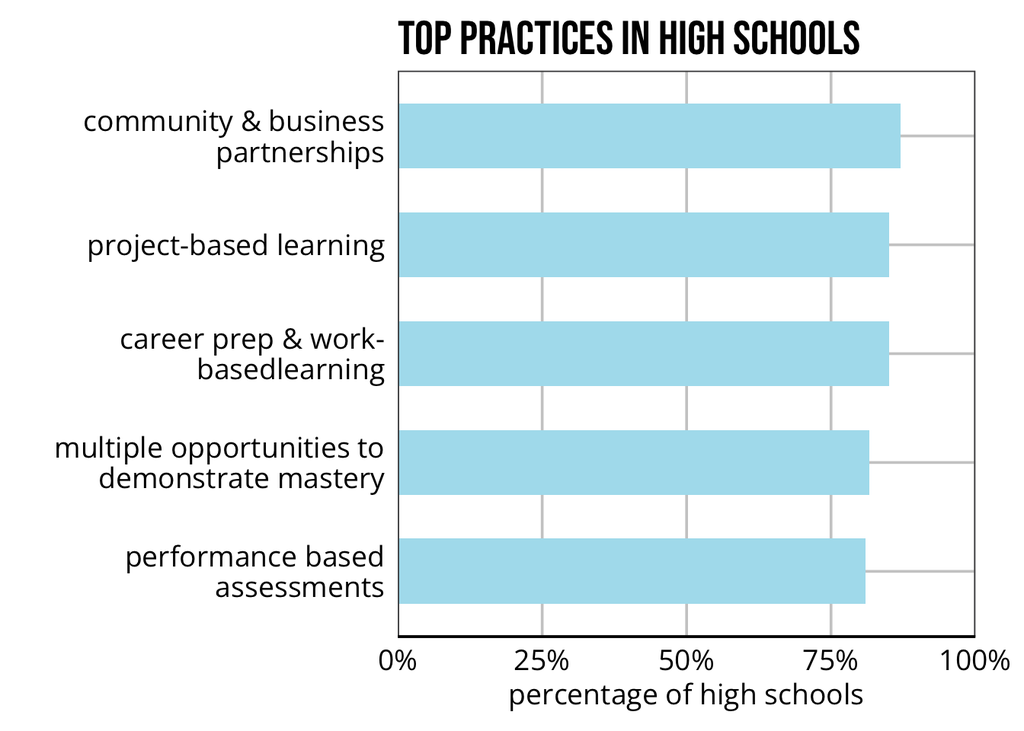

```r
#high schools
disag_high <- full %>%
  select(school_id, grades_high, starts_with("practices")) %>%
  filter(grades_high == 1) %>%
  pivot_longer(cols = starts_with("practices"),
               names_to = "tag",
               values_to = "n") %>%
  select(!school_id) %>%
  mutate(rate = rep(1, nrow(.))) %>%
  group_by(tag) %>%
  summarize(n = sum(n),
            rate = sum(rate),
            pct = n/rate) %>%
  ungroup() %>%
  arrange(desc(n)) %>%
  slice(1:5) %>%
  ggplot(., aes(reorder(tag, pct), pct)) +
  geom_col(fill = transcend_cols[4]) +
  scale_x_discrete(labels = label_tags(wrap = 25)) +
  coord_flip() +
  scale_y_continuous(limits = c(0, 1),
                     expand = c(0,0),
                     labels = scales::percent) +
  labs(title = "Top Practices in High Schools",
       x = "",
       y = "percentage of high schools")
disag_high
```

##By school type

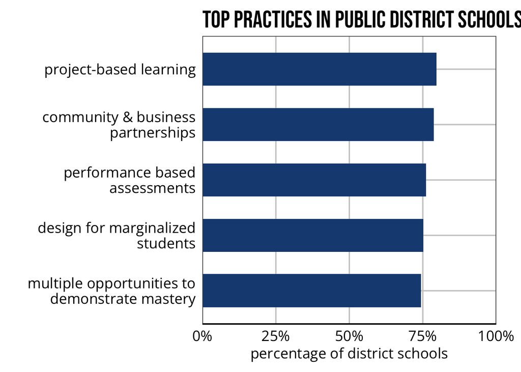

```r
disag_type <- full %>%
  select(school_id, type = school_descriptor, starts_with("practices")) %>%
  mutate(type = case_when(
    type == 1 ~ "District",
    type == 2 ~ "Charter",
    type == 3 ~ "Independent"
  )) %>%
  pivot_longer(cols = starts_with("practices"),
               names_to = "tag",
               values_to = "n") %>%
  select(!school_id) %>%
  mutate(rate = rep(1, nrow(.))) %>%
  group_by(type, tag) %>%
  summarize(n = sum(n),
            rate = sum(rate),
            pct = n/rate) %>%
  ungroup() %>%
  group_by(type) %>%
  arrange(desc(n), .by_group = TRUE) %>%
  slice(1:5)
#Public district schools
district_plot <- disag_type %>%
  filter(type == "District") %>%
  ggplot(., aes(reorder(tag, pct), pct)) +
  geom_col(fill = transcend_cols[1]) +
  scale_x_discrete(labels = label_tags(wrap = 25)) +
  coord_flip() +
  scale_y_continuous(limits = c(0, 1),
                     expand = c(0,0),
                     labels = scales::percent) +
  labs(title = "Top Practices in Public District Schools",
       x = "",
       y = "percentage of district schools")
district_plot
```

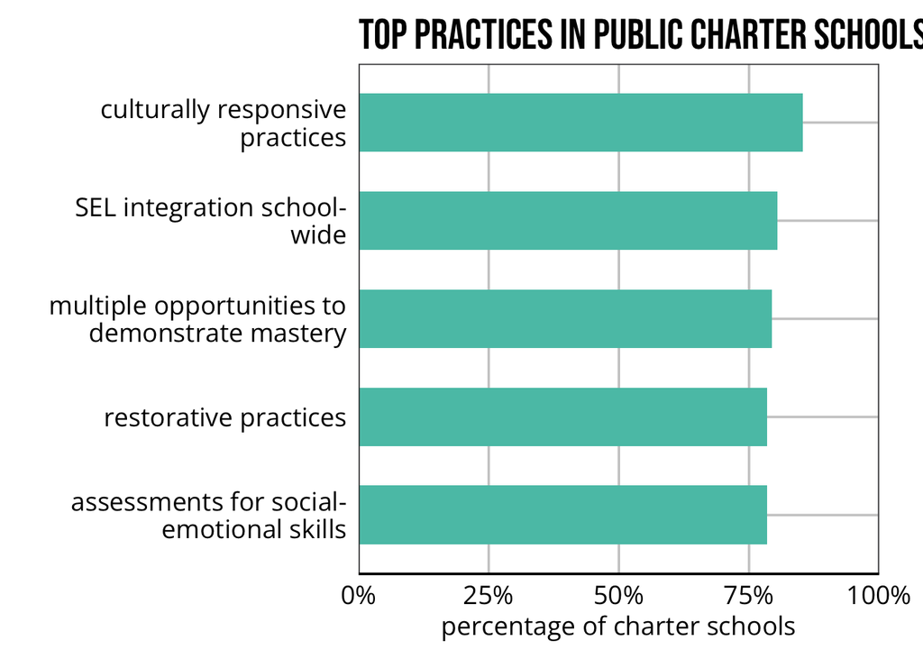

```r
#Public charter schools
charter_plot <- disag_type %>%
  filter(type == "Charter") %>%
  ggplot(., aes(reorder(tag, pct), pct)) +
  geom_col(fill = transcend_cols[2]) +
  scale_x_discrete(labels = label_tags(wrap = 25)) +
  coord_flip() +
  scale_y_continuous(limits = c(0, 1),
                     expand = c(0,0),
                     labels = scales::percent) +
  labs(title = "Top Practices in Public Charter Schools",
       x = "",
       y = "percentage of charter schools")
charter_plot
```

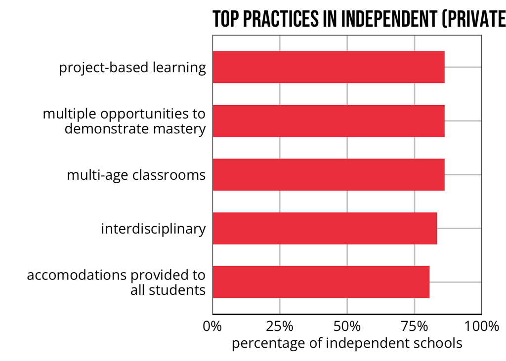

```r
#Independent schools
independent_plot <- disag_type %>%
  filter(type == "Independent") %>%
  ggplot(., aes(reorder(tag, pct), pct)) +
  geom_col(fill = transcend_cols[3]) +
  scale_x_discrete(labels = label_tags(wrap = 25)) +
  coord_flip() +
  scale_y_continuous(limits = c(0, 1),
                     expand = c(0,0),
                     labels = scales::percent) +
  labs(title = "Top Practices in Independent (Private) Schools",
       x = "",
       y = "percentage of independent schools")
independent_plot
```

##By descriptors

These plots are somewhat misleading and probably should not be displayed due to low N. For homeschools in particular, because there were only 4 schools that described themselves that way and 6 instances where they all selected the same tags, the plot displays a full 100% barchart for all 6 tags. Drawing any conclusions from this would not be a good idea, though.

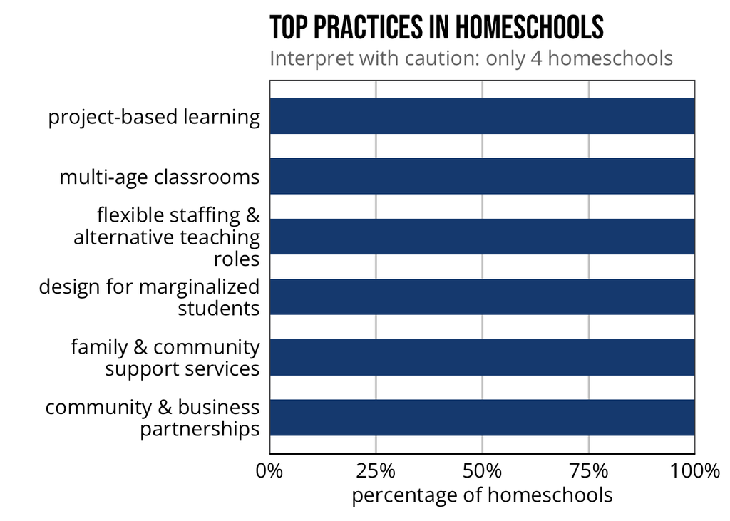

```r
#homeschool
disag_homeschool <- full %>%
  select(school_id, homeschool = school_descriptor_homeschool, starts_with("practices")) %>%
  filter(homeschool == 1) %>%
  pivot_longer(cols = starts_with("practices"),
               names_to = "tag",
               values_to = "n") %>%
  select(!school_id) %>%
  mutate(rate = rep(1, nrow(.))) %>%
  group_by(tag) %>%
  summarize(n = sum(n),
            rate = sum(rate),
            pct = n/rate) %>%
  ungroup() %>%
  arrange(desc(n)) %>%
  slice(1:6) %>% #pulled 6 because #5 had a tie with another practice -6 tags had 100% selection
  ggplot(., aes(reorder(tag, pct), pct)) +
  geom_col(fill = transcend_cols[1]) +
  scale_x_discrete(labels = label_tags(wrap = 25)) +
  coord_flip() +
  scale_y_continuous(limits = c(0, 1),
                     expand = c(0,0),
                     labels = scales::percent) +
  labs(title = "Top Practices in Homeschools",
       subtitle = "Interpret with caution: only 4 homeschools",
       x = "",
       y = "percentage of homeschools")
disag_homeschool
```

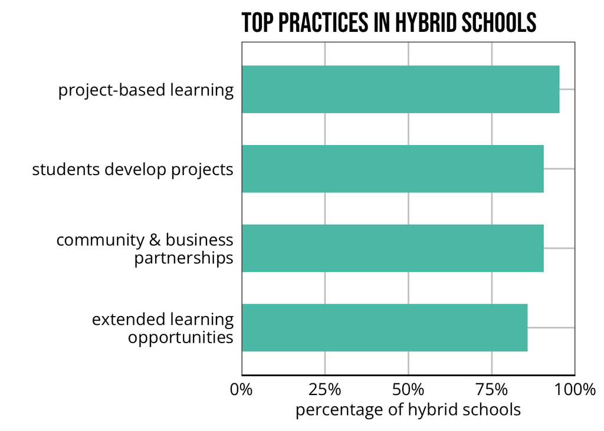

```r
#hybrid
disag_hybrid <- full %>%
  select(school_id, hybrid = school_descriptor_hybrid, starts_with("practices")) %>%
  filter(hybrid == 1) %>%
  pivot_longer(cols = starts_with("practices"),
               names_to = "tag",
               values_to = "n") %>%
  select(!school_id) %>%
  mutate(rate = rep(1, nrow(.))) %>%
  group_by(tag) %>%
  summarize(n = sum(n),
            rate = sum(rate),
            pct = n/rate) %>%
  ungroup() %>%
  arrange(desc(n)) %>%
  slice(1:4) %>% #pulled 4 because 7 tags shared #5 spot
  ggplot(., aes(reorder(tag, pct), pct)) +
  geom_col(fill = transcend_cols[2]) +
  scale_x_discrete(labels = label_tags(wrap = 25)) +
  coord_flip() +
  scale_y_continuous(limits = c(0, 1),
                     expand = c(0,0),
                     labels = scales::percent) +
  labs(title = "Top Practices in Hybrid Schools",
       x = "",
       y = "percentage of hybrid schools")
disag_hybrid
```

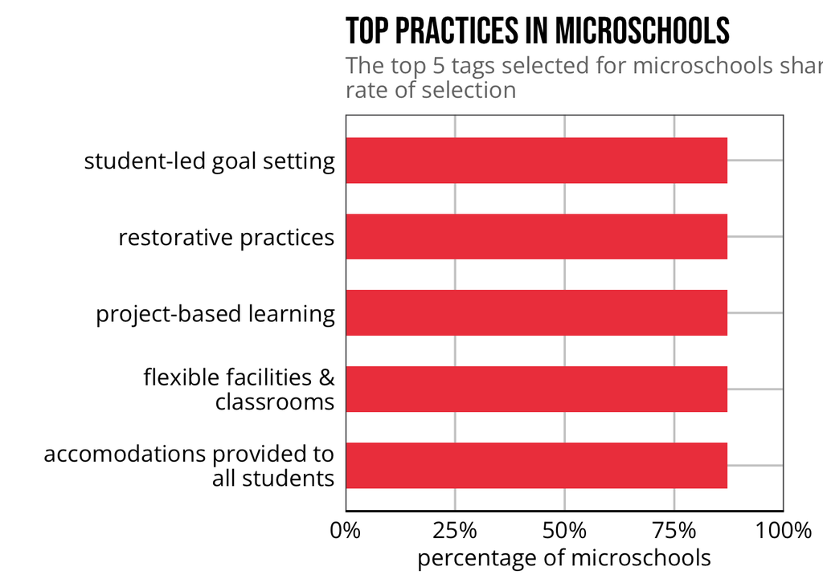

```r
#microschool
disag_micro <- full %>%
  select(school_id, micro = school_descriptor_microschool, starts_with("practices")) %>%
  filter(micro == 1) %>%
  pivot_longer(cols = starts_with("practices"),
               names_to = "tag",
               values_to = "n") %>%
  select(!school_id) %>%
  mutate(rate = rep(1, nrow(.))) %>%
  group_by(tag) %>%
  summarize(n = sum(n),
            rate = sum(rate),
            pct = n/rate) %>%
  ungroup() %>%
  arrange(desc(n)) %>%
  slice(1:5) %>% #top 5 had same rate of selection (87%)
  ggplot(., aes(reorder(tag, pct), pct)) +
  geom_col(fill = transcend_cols[3]) +
  scale_x_discrete(labels = label_tags(wrap = 25)) +
  coord_flip() +
  scale_y_continuous(limits = c(0, 1),
                     expand = c(0,0),
                     labels = scales::percent) +
  labs(title = "Top Practices in Microschools",
       subtitle = "The top 5 tags selected for microschools shared the same\nrate of selection",
       x = "",
       y = "percentage of microschools")
disag_micro
```

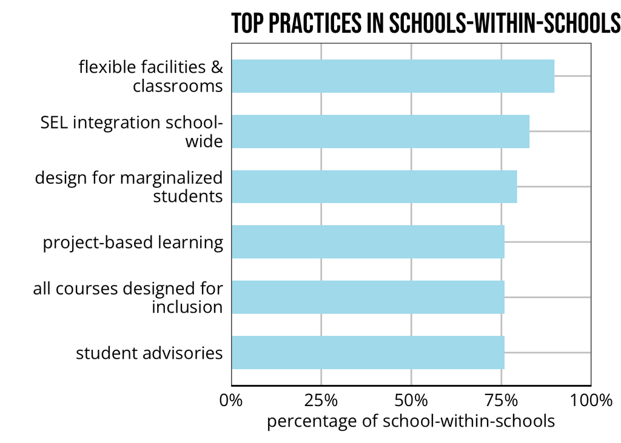

```r
#school within school
disag_sws <- full %>%
  select(school_id, sws = school_descriptor_sws, starts_with("practices")) %>%
  filter(sws == 1) %>%
  pivot_longer(cols = starts_with("practices"),
               names_to = "tag",
               values_to = "n") %>%
  select(!school_id) %>%
  mutate(rate = rep(1, nrow(.))) %>%
  group_by(tag) %>%
  summarize(n = sum(n),
            rate = sum(rate),
            pct = n/rate) %>%
  ungroup() %>%
  arrange(desc(n)) %>%
  slice(1:6) %>% #pulled 6 because tie at spot #5
  ggplot(., aes(reorder(tag, pct), pct)) +
  geom_col(fill = transcend_cols[4]) +
  scale_x_discrete(labels = label_tags(wrap = 25)) +
  coord_flip() +
  scale_y_continuous(limits = c(0, 1),
                     expand = c(0,0),
                     labels = scales::percent) +
  labs(title = "Top Practices in Schools-within-schools",
       x = "",
       y = "percentage of school-within-schools")
disag_sws
```

```r
#virtual
```

##By leadership team

I collapsed leadership team diversity variable in two:  
*predominantly White = 0-49% BIPOC leadership*  
predominantly BIPOC = 50% + BIPOC leadership

```r
disag_lead <- full %>%
  select(school_id, lead = leadership_diversity, starts_with("practices")) %>%
  filter(!lead == 0) %>%
  filter(!lead == 5) %>%
  mutate(lead = case_when(
    (lead == 1 | lead == 2) ~ "PWI",
    (lead == 3 | lead == 4) ~ "BIPOC"
  )) %>%
  pivot_longer(cols = starts_with("practices"),
               names_to = "tag",
               values_to = "n") %>%
  select(!school_id) %>%
  mutate(rate = rep(1, nrow(.))) %>%
  group_by(lead, tag) %>%
  summarize(n = sum(n),
            rate = sum(rate),
            pct = n/rate) %>%
  ungroup() %>%
  group_by(lead) %>%
  arrange(desc(n), .by_group = TRUE) %>%
  slice(1:6) #tie at spot #5 for both groups
```

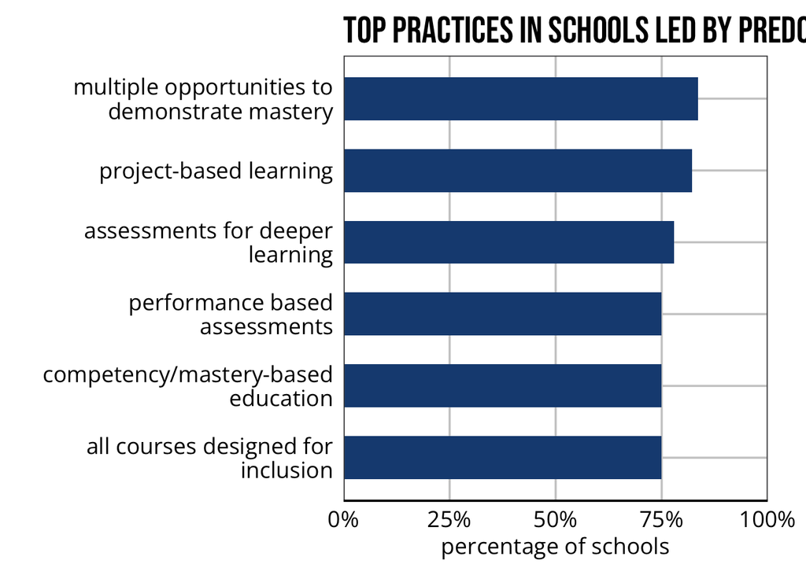

```r
#predominantly white
pwled_plot <- disag_lead %>%
  filter(lead == "PWI") %>%
  ggplot(., aes(reorder(tag, pct), pct)) +
  geom_col(fill = transcend_cols[1]) +
  scale_x_discrete(labels = label_tags(wrap = 25)) +
  coord_flip() +
  scale_y_continuous(limits = c(0, 1),
                     expand = c(0,0),
                     labels = scales::percent) +
  labs(title = "Top Practices in Schools led by Predominantly White Leadership Team",
       x = "",
       y = "percentage of schools")
pwled_plot
```

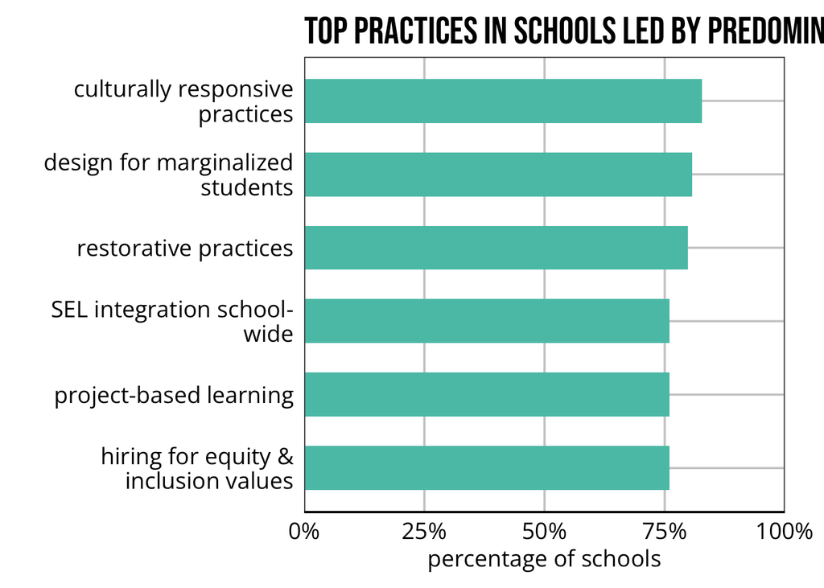

```r
#BIPOC-led
bipocled_plot <- disag_lead %>%
  filter(lead == "BIPOC") %>%
  ggplot(., aes(reorder(tag, pct), pct)) +
  geom_col(fill = transcend_cols[2]) +
  scale_x_discrete(labels = label_tags(wrap = 25)) +
  coord_flip() +
  scale_y_continuous(limits = c(0, 1),
                     expand = c(0,0),
                     labels = scales::percent) +
  labs(title = "Top Practices in Schools led by Predominantly BIPOC Leadership Team",
       x = "",
       y = "percentage of schools")
bipocled_plot
```

##By designing for specific student groups

The plots below pull from all schools that selected `design to meet the needs of students who have been marginalized` and the follow-up question which asks them to specify *which* marginalized student group they are designing for.

###Multilingual students

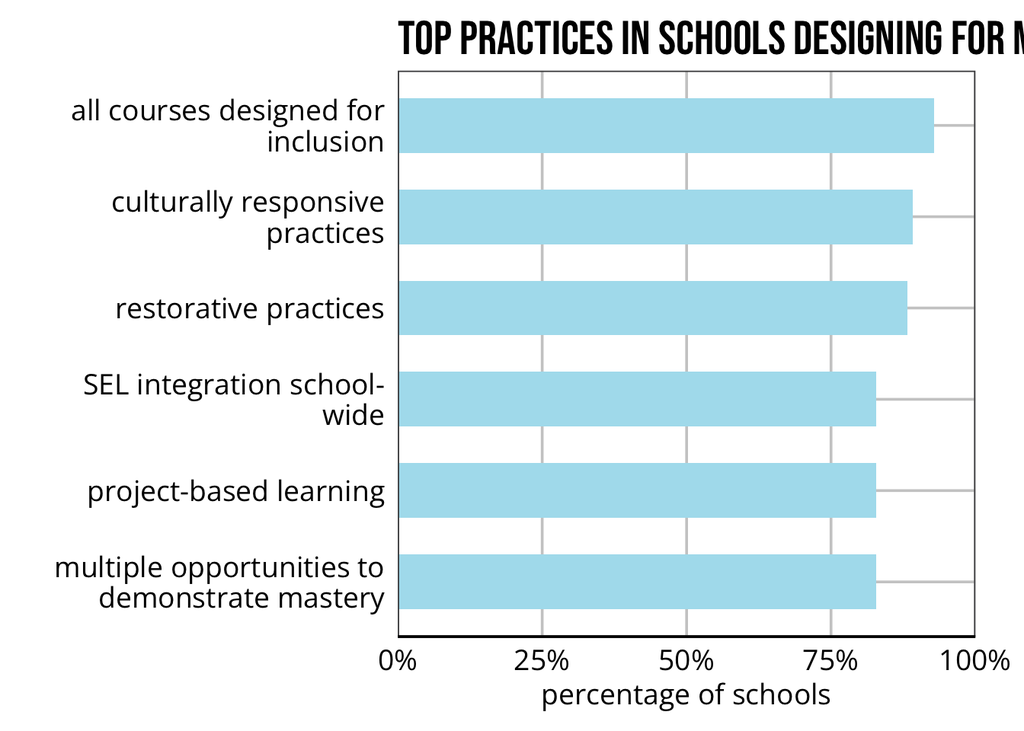

```r
disag_ml <- full %>%
  select(school_id, ml = focus_multilingual, starts_with("practices")) %>%
  filter(ml == 1) %>%
  select(!practices_design_marginalized) %>% #dropping since all will have chosen
  pivot_longer(cols = starts_with("practices"),
               names_to = "tag",
               values_to = "n") %>%
  select(!school_id) %>%
  mutate(rate = rep(1, nrow(.))) %>%
  group_by(tag) %>%
  summarize(n = sum(n),
            rate = sum(rate),
            pct = n/rate) %>%
  ungroup() %>%
  arrange(desc(n)) %>%
  slice(1:6) %>% #pulled 6 because tie at spot #5
  ggplot(., aes(reorder(tag, pct), pct)) +
  geom_col(fill = transcend_cols[4]) +
  scale_x_discrete(labels = label_tags(wrap = 25)) +
  coord_flip() +
  scale_y_continuous(limits = c(0, 1),
                     expand = c(0,0),
                     labels = scales::percent) +
  labs(title = "Top Practices in Schools Designing for Multilingual students",
       x = "",
       y = "percentage of schools")
disag_ml
```

###Students classified as English Learners

###Students with interrupted formal education

###Newcomer students

###BIPOC students

###Economically disadvantaged students

###Students in the foster care system

###Students experiencing houselessness

###Students in the juvenile justice system

###Students with disabilities

#What are the top *core* tags selected when disaggregated?

##By locale

##By level

##By school type

##By leadership team